# SpackPatternsTest

```python
import sys, os, getpass, warnings
warnings.filterwarnings('ignore')
#sys.path.append(os.path.abspath(os.path.join(os.path.dirname(os.path.realpath("__file__")), '..', 'src')))  # append parent directory to search path
from patterns.visualizer import Visualizer
```

Bring in data from database and annotate it with *locc*, *locc+*, *locc-*, *change-size-cos* = *1-similarity* (**expensive call**)

```python
vis = Visualizer(project_name='petsc', db_pwd=getpass.getpass(prompt='Database password:'))
vis.get_data()
```

```python
all_commits = vis.commit_data
all_commits.head()
```

| datetime | sha | branch | author | email | message | filepath | diff | year | month | day | doy | dow | locc | locc- | locc+ | change-size-cos |
| --- | --- | --- | --- | --- | --- | --- | --- | --- | --- | --- | --- | --- | --- | --- | --- | --- |
| 2021-02-10 11:02:01 | 9dddd24924da2034e9ad37bd0330bf8579e05078 | * main\n remotes/origin/HEAD -> origin/main\n... | Satish Balay | balay@mcs.anl.gov | git: switch default branch from 'master' to 'm... | .travis.yml | - - master\n+ - main\n--- a/CONTRIBUTING... | 2021 | 2 | 10 | 41 | Wednesday | 2 | 1 | 1 | 0.422650 |
| 2021-02-10 11:02:01 | 9dddd24924da2034e9ad37bd0330bf8579e05078 | * main\n remotes/origin/HEAD -> origin/main\n... | Satish Balay | balay@mcs.anl.gov | git: switch default branch from 'master' to 'm... | config/BuildSystem/config/package.py | - self.gitcommitmaster = None # Git ... | 2021 | 2 | 10 | 41 | Wednesday | 2 | 1 | 1 | 0.068583 |
| 2021-02-10 11:02:01 | 9dddd24924da2034e9ad37bd0330bf8579e05078 | * main\n remotes/origin/HEAD -> origin/main\n... | Satish Balay | balay@mcs.anl.gov | git: switch default branch from 'master' to 'm... | include/petscviewer.h | -PETSC_EXTERN PetscErrorCode PetscViewerFlowCo... | 2021 | 2 | 10 | 41 | Wednesday | 0 | 0 | 0 | 0.000000 |
| 2021-02-10 11:02:01 | 9dddd24924da2034e9ad37bd0330bf8579e05078 | * main\n remotes/origin/HEAD -> origin/main\n... | Satish Balay | balay@mcs.anl.gov | git: switch default branch from 'master' to 'm... | lib/petsc/bin/maint/builddist | -# builddist /sandbox/petsc/petsc.clone mast... | 2021 | 2 | 10 | 41 | Wednesday | 2 | 1 | 1 | 0.212274 |
| 2021-02-10 11:02:01 | 9dddd24924da2034e9ad37bd0330bf8579e05078 | * main\n remotes/origin/HEAD -> origin/main\n... | Satish Balay | balay@mcs.anl.gov | git: switch default branch from 'master' to 'm... | lib/petsc/bin/maint/lex.py | - self.lexre = None # Maste... | 2021 | 2 | 10 | 41 | Wednesday | 2 | 1 | 1 | 0.039915 |

## Remove all noncode files

The determination of what is code is made by including common suffixes, as well as checking manually a sampling of ECP projects for the suffixes used for things that can be labeled as code (vs. input simulation data, documentation, or generated files).

```python
vis.remove_noncode()
print("Removed %d noncode files!" % (all_commits.shape[0] - vis.commit_data.shape[0]))
vis.commit_data.head()
```

```
Removed 63487 noncode files!
```

| datetime | sha | branch | author | email | message | filepath | diff | year | month | day | doy | dow | locc | locc- | locc+ | change-size-cos |
| --- | --- | --- | --- | --- | --- | --- | --- | --- | --- | --- | --- | --- | --- | --- | --- | --- |
| 2021-02-10 11:02:01 | 9dddd24924da2034e9ad37bd0330bf8579e05078 | * main\n remotes/origin/HEAD -> origin/main\n... | Satish Balay | balay@mcs.anl.gov | git: switch default branch from 'master' to 'm... | .travis.yml | - - master\n+ - main\n--- a/CONTRIBUTING... | 2021 | 2 | 10 | 41 | Wednesday | 2 | 1 | 1 | 0.422650 |
| 2021-02-10 11:02:01 | 9dddd24924da2034e9ad37bd0330bf8579e05078 | * main\n remotes/origin/HEAD -> origin/main\n... | Satish Balay | balay@mcs.anl.gov | git: switch default branch from 'master' to 'm... | config/BuildSystem/config/package.py | - self.gitcommitmaster = None # Git ... | 2021 | 2 | 10 | 41 | Wednesday | 2 | 1 | 1 | 0.068583 |
| 2021-02-10 11:02:01 | 9dddd24924da2034e9ad37bd0330bf8579e05078 | * main\n remotes/origin/HEAD -> origin/main\n... | Satish Balay | balay@mcs.anl.gov | git: switch default branch from 'master' to 'm... | include/petscviewer.h | -PETSC_EXTERN PetscErrorCode PetscViewerFlowCo... | 2021 | 2 | 10 | 41 | Wednesday | 0 | 0 | 0 | 0.000000 |
| 2021-02-10 11:02:01 | 9dddd24924da2034e9ad37bd0330bf8579e05078 | * main\n remotes/origin/HEAD -> origin/main\n... | Satish Balay | balay@mcs.anl.gov | git: switch default branch from 'master' to 'm... | lib/petsc/bin/maint/lex.py | - self.lexre = None # Maste... | 2021 | 2 | 10 | 41 | Wednesday | 2 | 1 | 1 | 0.039915 |
| 2021-02-10 11:02:01 | 9dddd24924da2034e9ad37bd0330bf8579e05078 | * main\n remotes/origin/HEAD -> origin/main\n... | Satish Balay | balay@mcs.anl.gov | git: switch default branch from 'master' to 'm... | setup.py | - $ python -m pip install --no-deps https:/... | 2021 | 2 | 10 | 41 | Wednesday | 2 | 1 | 1 | 0.060414 |

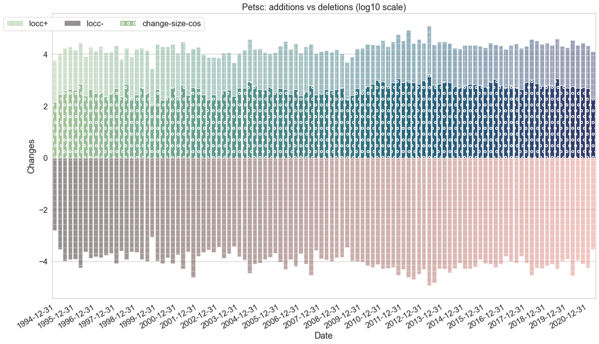

```python
df = vis.plot_overall_project_locc(time_range=None, log=True)
```

to focus on a given year and/or month, set *year* and *month* fields

```python
vis.set_year(2020)
vis.set_month(7)
```

to plot for a given year, provide *time_range='year'*

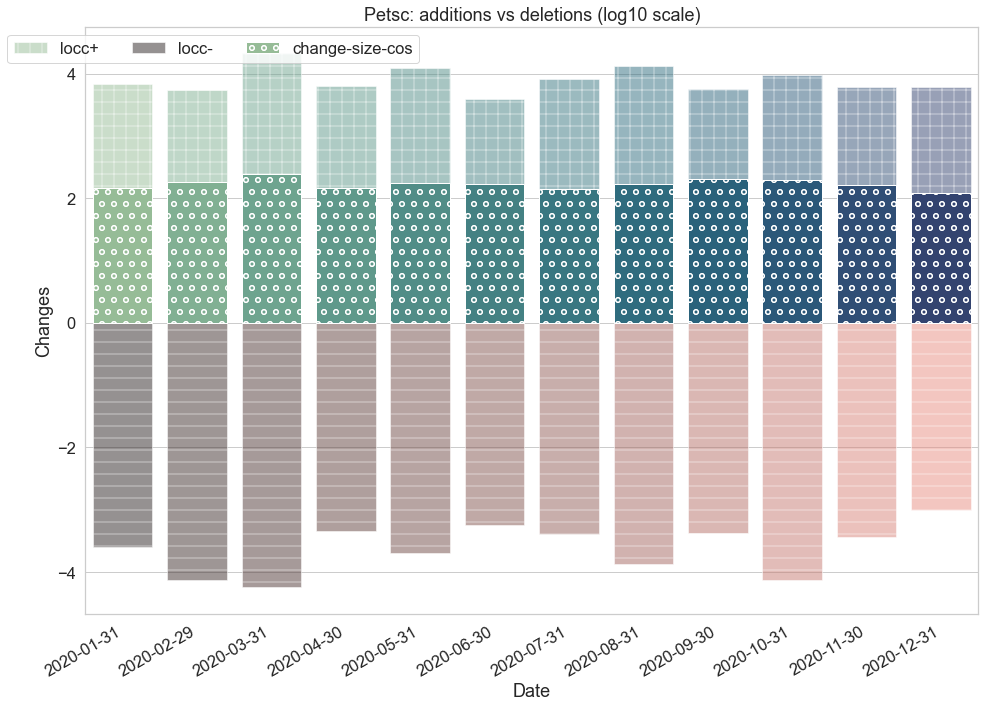

```python
df = vis.plot_overall_project_locc(time_range='year',log=True)
```

similarly to plot for a given month, set *time_range='month'*

| datetime | year | month | day | doy | locc | locc- | locc+ | change-size-cos | date |
| --- | --- | --- | --- | --- | --- | --- | --- | --- | --- |
| 2020-07-01 | 74740 | 259 | 37 | 6771 | 2787 | -3.130012 | 3.157759 | 1.316402 | 2020-07-01 |
| 2020-07-02 | 34340 | 119 | 34 | 3128 | 244 | -2.064458 | 2.107210 | 0.875185 | 2020-07-02 |
| 2020-07-03 | 24240 | 84 | 36 | 2220 | 231 | -1.857332 | 2.201397 | 0.703736 | 2020-07-03 |
| 2020-07-04 | 36360 | 126 | 72 | 3348 | 93 | -1.672098 | 1.662758 | 0.598078 | 2020-07-04 |
| 2020-07-05 | 44440 | 154 | 110 | 4114 | 254 | -1.963788 | 2.209515 | 0.771166 | 2020-07-05 |
| 2020-07-06 | 26260 | 91 | 78 | 2444 | 164 | -1.591065 | 2.096910 | 0.508461 | 2020-07-06 |
| 2020-07-07 | 14140 | 49 | 49 | 1323 | 140 | -1.748188 | 1.924279 | 0.542294 | 2020-07-07 |
| 2020-07-08 | 0 | 0 | 0 | 0 | 0 | inf | -inf | -inf | 2020-07-08 |
| 2020-07-09 | 0 | 0 | 0 | 0 | 0 | inf | -inf | -inf | 2020-07-09 |
| 2020-07-10 | 0 | 0 | 0 | 0 | 0 | inf | -inf | -inf | 2020-07-10 |
| 2020-07-11 | 2020 | 7 | 11 | 193 | 4 | -0.000000 | 0.477121 | -1.110472 | 2020-07-11 |
| 2020-07-12 | 20200 | 70 | 120 | 1940 | 89 | -1.531479 | 1.740363 | 0.619957 | 2020-07-12 |
| 2020-07-13 | 24240 | 84 | 156 | 2340 | 140 | -1.146128 | 2.100371 | 0.772968 | 2020-07-13 |
| 2020-07-14 | 42420 | 147 | 294 | 4116 | 682 | -1.505150 | 2.812913 | 1.221739 | 2020-07-14 |
| 2020-07-15 | 14140 | 49 | 105 | 1379 | 184 | -1.908485 | 2.012837 | 0.603149 | 2020-07-15 |
| 2020-07-16 | 2020 | 7 | 16 | 198 | 20 | -0.698970 | 1.176091 | -0.546212 | 2020-07-16 |
| 2020-07-17 | 40400 | 140 | 340 | 3980 | 190 | -1.431364 | 2.212188 | 0.767571 | 2020-07-17 |
| 2020-07-18 | 24240 | 84 | 216 | 2400 | 2239 | -1.491362 | 3.343999 | 0.677474 | 2020-07-18 |
| 2020-07-19 | 70700 | 245 | 665 | 7035 | 225 | -1.986772 | 2.107210 | 0.558030 | 2020-07-19 |
| 2020-07-20 | 0 | 0 | 0 | 0 | 0 | inf | -inf | -inf | 2020-07-20 |
| 2020-07-21 | 24240 | 84 | 252 | 2436 | 238 | -1.924279 | 2.187521 | 0.825768 | 2020-07-21 |
| 2020-07-22 | 14140 | 49 | 154 | 1428 | 33 | -0.698970 | 1.447158 | 0.679931 | 2020-07-22 |
| 2020-07-23 | 22220 | 77 | 253 | 2255 | 23 | -0.698970 | 1.255273 | 0.932289 | 2020-07-23 |
| 2020-07-24 | 4040 | 14 | 48 | 412 | 12 | -0.698970 | 0.845098 | -0.307399 | 2020-07-24 |
| 2020-07-25 | 0 | 0 | 0 | 0 | 0 | inf | -inf | -inf | 2020-07-25 |
| 2020-07-26 | 6060 | 21 | 78 | 624 | 3 | inf | 0.477121 | 0.301030 | 2020-07-26 |
| 2020-07-27 | 90900 | 315 | 1215 | 9405 | 1760 | -2.298853 | 3.193403 | 1.122437 | 2020-07-27 |
| 2020-07-28 | 14140 | 49 | 196 | 1470 | 470 | -1.397940 | 2.648360 | 0.612113 | 2020-07-28 |
| 2020-07-29 | 14140 | 49 | 203 | 1477 | 436 | -0.698970 | 2.634477 | 0.520003 | 2020-07-29 |
| 2020-07-30 | 24240 | 84 | 360 | 2544 | 61 | -1.342423 | 1.591065 | 0.338199 | 2020-07-30 |
| 2020-07-31 | 2020 | 7 | 31 | 213 | 0 | inf | -inf | -inf | 2020-07-31 |

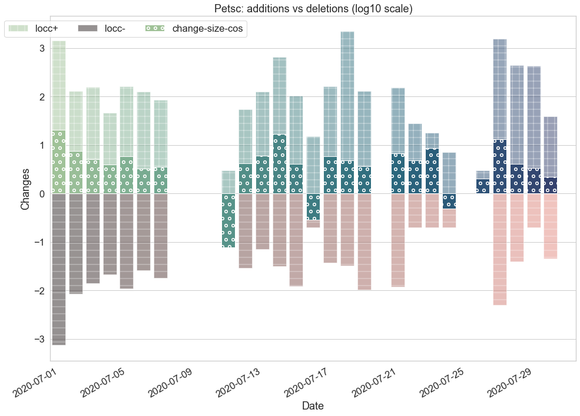

```python
vis.plot_overall_project_locc(time_range='month',log=True)
```

### Averages: Total changed lines over time

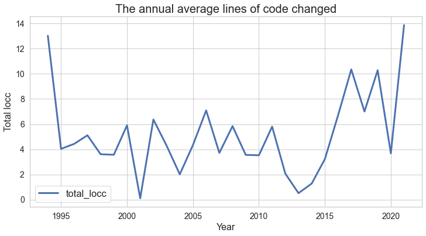

```python
vis.plot_total_locc_avg()
```

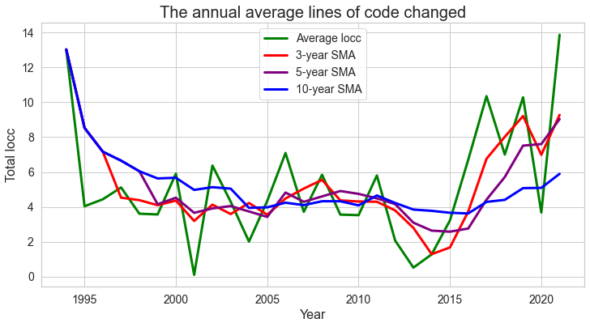

```python
vis.plot_total_locc_moving_avgs()
```

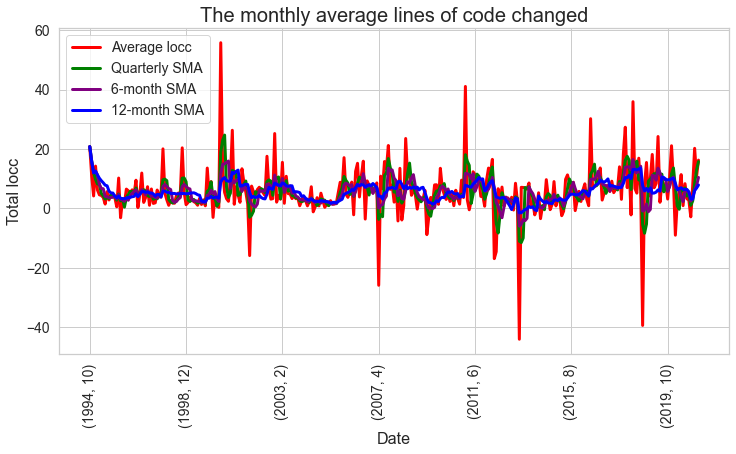

```python
vis.plot_total_locc_moving_avgs_M()
```

## Total changed lines over time

This reflects changed lines of code as reported in git commit diffs.

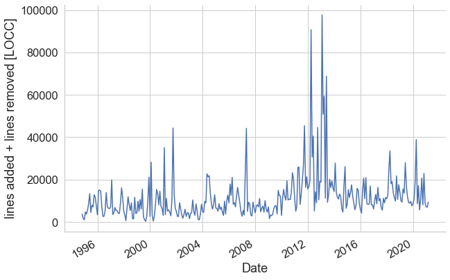

```python
df = vis.plot_project_locc_line()
```

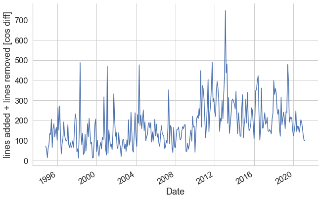

```python
df2 = vis.plot_project_locc_line(locc=False)
```

| datetime | year | month | day | doy | locc | locc- | locc+ | change-size-cos |
| --- | --- | --- | --- | --- | --- | --- | --- | --- |
| 1994-10-31 00:00:00+00:00 | 209370 | 1050 | 1471 | 30136 | 3703 | 256 | 3447 | 72.481236 |
| 1994-11-30 00:00:00+00:00 | 175472 | 968 | 1537 | 28289 | 1676 | 120 | 1556 | 55.901093 |
| 1994-12-31 00:00:00+00:00 | 83748 | 504 | 888 | 14916 | 966 | 250 | 716 | 14.274803 |
| 1995-01-31 00:00:00+00:00 | 261345 | 131 | 1927 | 1927 | 4711 | 886 | 3825 | 64.168758 |
| 1995-02-28 00:00:00+00:00 | 438900 | 440 | 2170 | 8990 | 3691 | 816 | 2875 | 79.563827 |

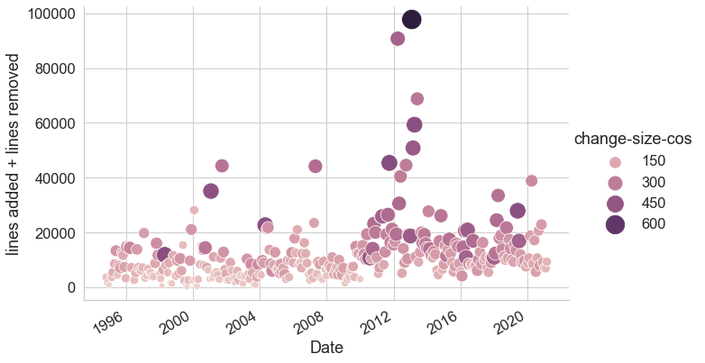

```python
import seaborn as sns
sns.set(font_scale=1.5)
with sns.axes_style("whitegrid"):
    g = sns.relplot(data=df2, x="datetime", y="locc", size="change-size-cos", hue="change-size-cos", sizes=(50, 500),
                    height=6, aspect=1.5, kind="scatter")
    g.ax.set_xlabel('Date')
    g.ax.set_ylabel('lines added + lines removed')
    g.fig.autofmt_xdate()
    g.fig.show()
df.head()
```

### Using a distance metric to adjust the size of the changes

We use the python textdistance module. The following algorithms have been integrated with the visualizer.

```
'cos', 'hamming', 'damerau_levenshtein', 'jaccard', 'jaro', 'jaro_winkler', 'bag', 'editex'
```

| datetime | year | month | day | doy | locc | locc- | locc+ | change-size-cos | change-size-jaccard |
| --- | --- | --- | --- | --- | --- | --- | --- | --- | --- |
| 1994-10-31 00:00:00+00:00 | 209370 | 1050 | 1471 | 30136 | 3703 | 256 | 3447 | 72.481236 | 76.134082 |
| 1994-11-30 00:00:00+00:00 | 175472 | 968 | 1537 | 28289 | 1676 | 120 | 1556 | 55.901093 | 60.270564 |
| 1994-12-31 00:00:00+00:00 | 83748 | 504 | 888 | 14916 | 966 | 250 | 716 | 14.274803 | 18.796744 |
| 1995-01-31 00:00:00+00:00 | 261345 | 131 | 1927 | 1927 | 4711 | 886 | 3825 | 64.168758 | 73.197845 |
| 1995-02-28 00:00:00+00:00 | 438900 | 440 | 2170 | 8990 | 3691 | 816 | 2875 | 79.563827 | 96.445218 |

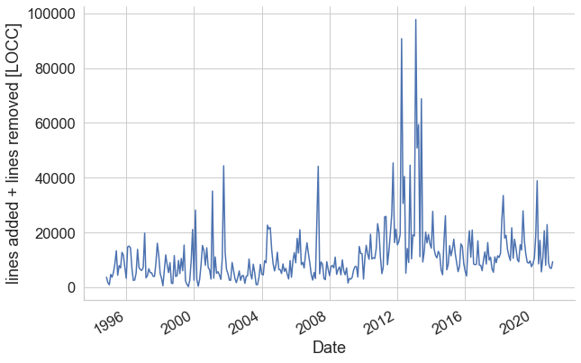

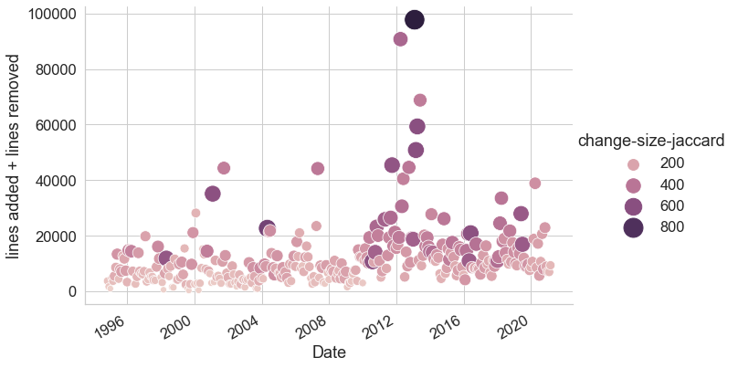

```python
diff_alg = 'jaccard'
df = vis.plot_project_locc_line(diff_alg=diff_alg, log=False)
import seaborn as sns
sns.set(font_scale=1.5)
with sns.axes_style("whitegrid"):
    g = sns.relplot(data=df, x="datetime", y="locc", size="change-size-%s" % diff_alg, hue="change-size-%s" % diff_alg, sizes=(50, 500),
                    height=6, aspect=1.5, kind="scatter")
    g.ax.set_xlabel('Date')
    g.ax.set_ylabel('lines added + lines removed')
    g.fig.autofmt_xdate()
    g.fig.show()
df.head()
```

## Change size over time

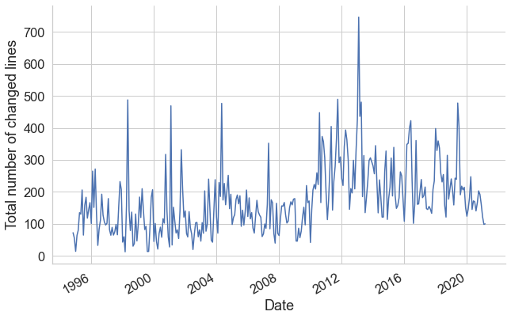

```python
df = vis.plot_proj_change_size(time_range=None)
```

Similarly, we can 'zoom' into a specific year

```
(                              year  month    day     doy   locc  locc-  locc+  \
 datetime
 2020-01-31 00:00:00+00:00   844360    418   7493    7493  10716   3923   6793
 2020-02-29 00:00:00+00:00  1183720   1172  10834   29000  18854  13342   5512
 2020-03-31 00:00:00+00:00  1304920   1938  11452   50212  38870  17703  21167
 2020-04-30 00:00:00+00:00   860520   1704   6162   44928   8551   2235   6316
 2020-05-31 00:00:00+00:00  1018080   2520   7240   68224  17151   5028  12123
 2020-06-30 00:00:00+00:00   991820   2946   6449   81081   5632   1758   3874
 2020-07-31 00:00:00+00:00   711040   2464   5129   69193  10722   2443   8279
 2020-08-31 00:00:00+00:00  2147260   8504  18655  245074  20661   7581  13080
 2020-09-30 00:00:00+00:00  1106960   4932   7658  141370   8033   2337   5696
 2020-10-31 00:00:00+00:00  2185640  10820  11026  307494  22903  13594   9309
 2020-11-30 00:00:00+00:00   707000   3850   4725  111475   8962   2795   6167
 2020-12-31 00:00:00+00:00   484800   2880   4297   84697   7057   1009   6048

                            change-size-cos  change-size-jaccard
 datetime
 2020-01-31 00:00:00+00:00       146.546598           179.645419
 2020-02-29 00:00:00+00:00       181.343990           211.197419
 2020-03-31 00:00:00+00:00       247.534156           285.928545
 2020-04-30 00:00:00+00:00       145.069736           182.039722
 2020-05-31 00:00:00+00:00       171.849259           212.838240
 2020-06-30 00:00:00+00:00       169.244267           215.745918
 2020-07-31 00:00:00+00:00       140.586141           167.395812
 2020-08-31 00:00:00+00:00       166.180764           213.976611
 2020-09-30 00:00:00+00:00       203.205732           248.594349
 2020-10-31 00:00:00+00:00       191.872317           245.055701
 2020-11-30 00:00:00+00:00       161.196015           184.382601
 2020-12-31 00:00:00+00:00       122.331873           141.052195  ,
 <AxesSubplot:xlabel='Date', ylabel='Total number of changed lines'>)
```

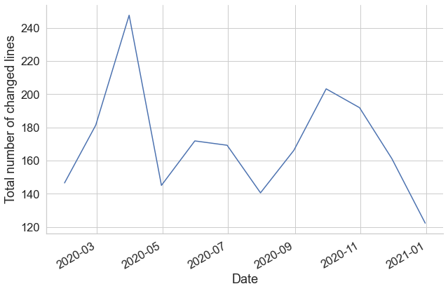

```python
vis.plot_proj_change_size(time_range='year')
```

Or a specific year range

```
(                              year  month    day     doy   locc  locc-  locc+  \
 datetime
 2018-01-31 00:00:00+00:00  1626508    806  13285   13285  12456   6061   6395
 2018-02-28 00:00:00+00:00  1660814   1646  12917   38430  24498   9207  15291
 2018-03-31 00:00:00+00:00  1713282   2547  13914   64005  33517  17861  15656
 2018-04-30 00:00:00+00:00  2088630   4140  14356  107506  17982   5851  12131
 2018-05-31 00:00:00+00:00  1186584   2940   9623   80183  18984   7209  11775
 2018-06-30 00:00:00+00:00  1374258   4086  11777  114608  13877   4456   9421
 2018-07-31 00:00:00+00:00   760786   2639   5715   73952  11461   3391   8070
 2018-08-31 00:00:00+00:00   653832   2592   5270   73958   9772   3542   6230
 2018-09-30 00:00:00+00:00  1731444   7722  11764  220258  21729  11633  10096
 2018-10-31 00:00:00+00:00   984784   4880   8045  141269  10605   3756   6849
 2018-11-30 00:00:00+00:00   988820   5390   7502  156462  17527   4819  12708
 2018-12-31 00:00:00+00:00  1063486   6324   9424  185442  14150   6157   7993
 2019-01-31 00:00:00+00:00   860094    426   7158    7158  10041   2667   7374
 2019-02-28 00:00:00+00:00   791448    784   4844   16996   9312   2701   6611
 2019-03-31 00:00:00+00:00  1354749   2013  10470   50059  15532   6890   8642
 2019-04-30 00:00:00+00:00  1231590   2440  10613   65513  13603   5063   8540
 2019-05-31 00:00:00+00:00  2547978   6310  25282  176722  27941   6353  21588
 2019-06-30 00:00:00+00:00  2535864   7536  15688  205344  16911   7427   9484
 2019-07-31 00:00:00+00:00  1215438   4214   8521  117483  11984   3944   8040
 2019-08-31 00:00:00+00:00  1090260   4320   7879  122359   9092   2763   6329
 2019-09-30 00:00:00+00:00  1237647   5517  10010  158969   8852   2815   6037
 2019-10-31 00:00:00+00:00  1393110   6900  10699  199069   9643   2987   6656
 2019-11-30 00:00:00+00:00   807600   4400   5418  127018   7517   1798   5719
 2019-12-31 00:00:00+00:00   547149   3252   3568   94082   8709   3368   5341
 2020-01-31 00:00:00+00:00   844360    418   7493    7493  10716   3923   6793
 2020-02-29 00:00:00+00:00  1183720   1172  10834   29000  18854  13342   5512
 2020-03-31 00:00:00+00:00  1304920   1938  11452   50212  38870  17703  21167
 2020-04-30 00:00:00+00:00   860520   1704   6162   44928   8551   2235   6316
 2020-05-31 00:00:00+00:00  1018080   2520   7240   68224  17151   5028  12123
 2020-06-30 00:00:00+00:00   991820   2946   6449   81081   5632   1758   3874
 2020-07-31 00:00:00+00:00   711040   2464   5129   69193  10722   2443   8279
 2020-08-31 00:00:00+00:00  2147260   8504  18655  245074  20661   7581  13080
 2020-09-30 00:00:00+00:00  1106960   4932   7658  141370   8033   2337   5696
 2020-10-31 00:00:00+00:00  2185640  10820  11026  307494  22903  13594   9309
 2020-11-30 00:00:00+00:00   707000   3850   4725  111475   8962   2795   6167
 2020-12-31 00:00:00+00:00   484800   2880   4297   84697   7057   1009   6048

                            change-size-cos  change-size-jaccard
```

[output cut: 23 more lines]

```
 2019-11-30 00:00:00+00:00       151.117086           172.277108
 2019-12-31 00:00:00+00:00       123.905852           145.439661
 2020-01-31 00:00:00+00:00       146.546598           179.645419
 2020-02-29 00:00:00+00:00       181.343990           211.197419
 2020-03-31 00:00:00+00:00       247.534156           285.928545
 2020-04-30 00:00:00+00:00       145.069736           182.039722
 2020-05-31 00:00:00+00:00       171.849259           212.838240
 2020-06-30 00:00:00+00:00       169.244267           215.745918
 2020-07-31 00:00:00+00:00       140.586141           167.395812
 2020-08-31 00:00:00+00:00       166.180764           213.976611
 2020-09-30 00:00:00+00:00       203.205732           248.594349
 2020-10-31 00:00:00+00:00       191.872317           245.055701
 2020-11-30 00:00:00+00:00       161.196015           184.382601
 2020-12-31 00:00:00+00:00       122.331873           141.052195  ,
 <AxesSubplot:xlabel='Date', ylabel='Total number of changed lines'>)
```

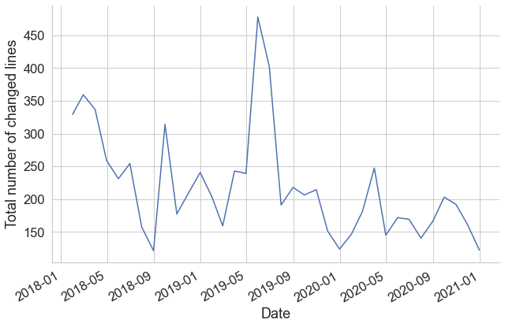

```python
vis.select_year_range(2018,2020)
vis.plot_proj_change_size(time_range='year-year')
```

we can zoom into a month

```
(                            year  month   day   doy  locc  locc-  locc+  \
 datetime
 2020-07-01 00:00:00+00:00  74740    259    37  6771  2787   1349   1438
 2020-07-02 00:00:00+00:00  34340    119    34  3128   244    116    128
 2020-07-03 00:00:00+00:00  24240     84    36  2220   231     72    159
 2020-07-04 00:00:00+00:00  36360    126    72  3348    93     47     46
 2020-07-05 00:00:00+00:00  44440    154   110  4114   254     92    162
 2020-07-06 00:00:00+00:00  26260     91    78  2444   164     39    125
 2020-07-07 00:00:00+00:00  14140     49    49  1323   140     56     84
 2020-07-08 00:00:00+00:00      0      0     0     0     0      0      0
 2020-07-09 00:00:00+00:00      0      0     0     0     0      0      0
 2020-07-10 00:00:00+00:00      0      0     0     0     0      0      0
 2020-07-11 00:00:00+00:00   2020      7    11   193     4      1      3
 2020-07-12 00:00:00+00:00  20200     70   120  1940    89     34     55
 2020-07-13 00:00:00+00:00  24240     84   156  2340   140     14    126
 2020-07-14 00:00:00+00:00  42420    147   294  4116   682     32    650
 2020-07-15 00:00:00+00:00  14140     49   105  1379   184     81    103
 2020-07-16 00:00:00+00:00   2020      7    16   198    20      5     15
 2020-07-17 00:00:00+00:00  40400    140   340  3980   190     27    163
 2020-07-18 00:00:00+00:00  24240     84   216  2400  2239     31   2208
 2020-07-19 00:00:00+00:00  70700    245   665  7035   225     97    128
 2020-07-20 00:00:00+00:00      0      0     0     0     0      0      0
 2020-07-21 00:00:00+00:00  24240     84   252  2436   238     84    154
 2020-07-22 00:00:00+00:00  14140     49   154  1428    33      5     28
 2020-07-23 00:00:00+00:00  22220     77   253  2255    23      5     18
 2020-07-24 00:00:00+00:00   4040     14    48   412    12      5      7
 2020-07-25 00:00:00+00:00      0      0     0     0     0      0      0
 2020-07-26 00:00:00+00:00   6060     21    78   624     3      0      3
 2020-07-27 00:00:00+00:00  90900    315  1215  9405  1760    199   1561
 2020-07-28 00:00:00+00:00  14140     49   196  1470   470     25    445
 2020-07-29 00:00:00+00:00  14140     49   203  1477   436      5    431
 2020-07-30 00:00:00+00:00  24240     84   360  2544    61     22     39
 2020-07-31 00:00:00+00:00   2020      7    31   213     0      0      0

                            change-size-cos  change-size-jaccard
 datetime
 2020-07-01 00:00:00+00:00        20.720565            22.190780
 2020-07-02 00:00:00+00:00         7.502137             8.448589
 2020-07-03 00:00:00+00:00         5.055173             6.822246
 2020-07-04 00:00:00+00:00         3.963490             6.102331
```

[output cut: 13 more lines]

```
 2020-07-18 00:00:00+00:00         4.758540             5.895196
 2020-07-19 00:00:00+00:00         3.614348             4.836381
 2020-07-20 00:00:00+00:00         0.000000             0.000000
 2020-07-21 00:00:00+00:00         6.695266             7.150031
 2020-07-22 00:00:00+00:00         4.785536             5.242023
 2020-07-23 00:00:00+00:00         8.556362             8.956735
 2020-07-24 00:00:00+00:00         0.492721             0.850406
 2020-07-25 00:00:00+00:00         0.000000             0.000000
 2020-07-26 00:00:00+00:00         2.000000             2.000000
 2020-07-27 00:00:00+00:00        13.256746            16.763655
 2020-07-28 00:00:00+00:00         4.093672             4.627023
 2020-07-29 00:00:00+00:00         3.311333             3.572992
 2020-07-30 00:00:00+00:00         2.178709             3.048556
 2020-07-31 00:00:00+00:00         0.000000             0.000000  ,
 <AxesSubplot:xlabel='Date', ylabel='Total number of changed lines'>)
```

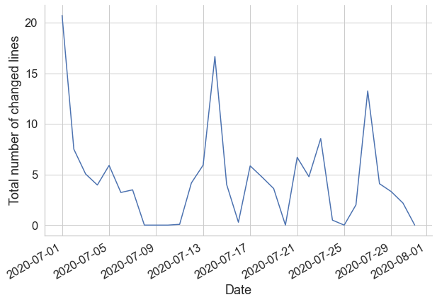

```python
vis.plot_proj_change_size(time_range='month')
```

Or a month range

```
(                              year  month    day     doy   locc  locc-  locc+  \
 datetime
 2018-05-31 00:00:00+00:00  1186584   2940   9623   80183  18984   7209  11775
 2018-06-30 00:00:00+00:00  1374258   4086  11777  114608  13877   4456   9421
 2018-07-31 00:00:00+00:00   760786   2639   5715   73952  11461   3391   8070
 2018-08-31 00:00:00+00:00   653832   2592   5270   73958   9772   3542   6230
 2018-09-30 00:00:00+00:00  1731444   7722  11764  220258  21729  11633  10096
 2018-10-31 00:00:00+00:00   984784   4880   8045  141269  10605   3756   6849
 2018-11-30 00:00:00+00:00   988820   5390   7502  156462  17527   4819  12708
 2018-12-31 00:00:00+00:00        0      0      0       0      0      0      0
 2019-01-31 00:00:00+00:00        0      0      0       0      0      0      0
 2019-02-28 00:00:00+00:00        0      0      0       0      0      0      0
 2019-03-31 00:00:00+00:00        0      0      0       0      0      0      0
 2019-04-30 00:00:00+00:00        0      0      0       0      0      0      0
 2019-05-31 00:00:00+00:00  2547978   6310  25282  176722  27941   6353  21588
 2019-06-30 00:00:00+00:00  2535864   7536  15688  205344  16911   7427   9484
 2019-07-31 00:00:00+00:00  1215438   4214   8521  117483  11984   3944   8040
 2019-08-31 00:00:00+00:00  1090260   4320   7879  122359   9092   2763   6329
 2019-09-30 00:00:00+00:00  1237647   5517  10010  158969   8852   2815   6037
 2019-10-31 00:00:00+00:00  1393110   6900  10699  199069   9643   2987   6656
 2019-11-30 00:00:00+00:00   807600   4400   5418  127018   7517   1798   5719
 2019-12-31 00:00:00+00:00        0      0      0       0      0      0      0
 2020-01-31 00:00:00+00:00        0      0      0       0      0      0      0
 2020-02-29 00:00:00+00:00        0      0      0       0      0      0      0
 2020-03-31 00:00:00+00:00        0      0      0       0      0      0      0
 2020-04-30 00:00:00+00:00        0      0      0       0      0      0      0
 2020-05-31 00:00:00+00:00  1018080   2520   7240   68224  17151   5028  12123
 2020-06-30 00:00:00+00:00   991820   2946   6449   81081   5632   1758   3874
 2020-07-31 00:00:00+00:00   711040   2464   5129   69193  10722   2443   8279
 2020-08-31 00:00:00+00:00  2147260   8504  18655  245074  20661   7581  13080
 2020-09-30 00:00:00+00:00  1106960   4932   7658  141370   8033   2337   5696
 2020-10-31 00:00:00+00:00  2185640  10820  11026  307494  22903  13594   9309
 2020-11-30 00:00:00+00:00   707000   3850   4725  111475   8962   2795   6167

                            change-size-cos  change-size-jaccard
 datetime
 2018-05-31 00:00:00+00:00       231.114813           277.224357
 2018-06-30 00:00:00+00:00       254.299413           306.319088
 2018-07-31 00:00:00+00:00       157.521887           185.269077
 2018-08-31 00:00:00+00:00       121.331739           149.240861
```

[output cut: 13 more lines]

```
 2019-10-31 00:00:00+00:00       214.446717           268.967195
 2019-11-30 00:00:00+00:00       151.117086           172.277108
 2019-12-31 00:00:00+00:00         0.000000             0.000000
 2020-01-31 00:00:00+00:00         0.000000             0.000000
 2020-02-29 00:00:00+00:00         0.000000             0.000000
 2020-03-31 00:00:00+00:00         0.000000             0.000000
 2020-04-30 00:00:00+00:00         0.000000             0.000000
 2020-05-31 00:00:00+00:00       171.849259           212.838240
 2020-06-30 00:00:00+00:00       169.244267           215.745918
 2020-07-31 00:00:00+00:00       140.586141           167.395812
 2020-08-31 00:00:00+00:00       166.180764           213.976611
 2020-09-30 00:00:00+00:00       203.205732           248.594349
 2020-10-31 00:00:00+00:00       191.872317           245.055701
 2020-11-30 00:00:00+00:00       161.196015           184.382601  ,
 <AxesSubplot:xlabel='Date', ylabel='Total number of changed lines'>)
```

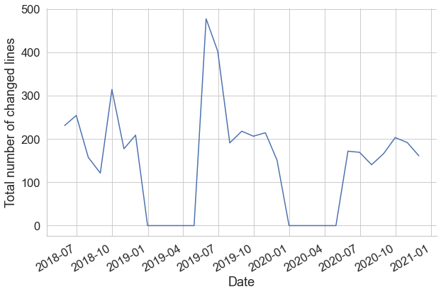

```python
vis.select_month_range(5,11)
vis.plot_proj_change_size(time_range='month-month')
```

## More patterns

Here we look at a combination of the the high-churn and domain champion patterns. Basically we are focusing on the files that have the most changes and restricting the developers by those with the biggest contributions.

| author filepath | Barry Smith | Matthew Knepley | Matthew G. Knepley | Hong Zhang | Satish Balay | Matthew G Knepley | Jed Brown | Stefano Zampini | Karl Rupp | Lisandro Dalcin |
| --- | --- | --- | --- | --- | --- | --- | --- | --- | --- | --- |
| src/dm/dt/interface/dtfe.c | 354 | 3 | 15235 | 0 | 15 | 0 | 1644 | 0 | 4 | 7 |
| src/dm/impls/co...les/tests/ex1.c | 0 | 0 | 0 | 0 | 0 | 44534 | 11 | 0 | 0 | 0 |
| src/dm/impls/co...mplex/ctetgen.c | 395 | 0 | 0 | 0 | 17052 | 17315 | 6282 | 0 | 0 | 0 |
| src/dm/impls/pl...ex/plexrefine.c | 40 | 2 | 20870 | 0 | 0 | 0 | 49 | 7229 | 0 | 50 |
| src/dm/impls/plex/plex.c | 470 | 29 | 14547 | 0 | 8 | 5473 | 756 | 705 | 712 | 258 |

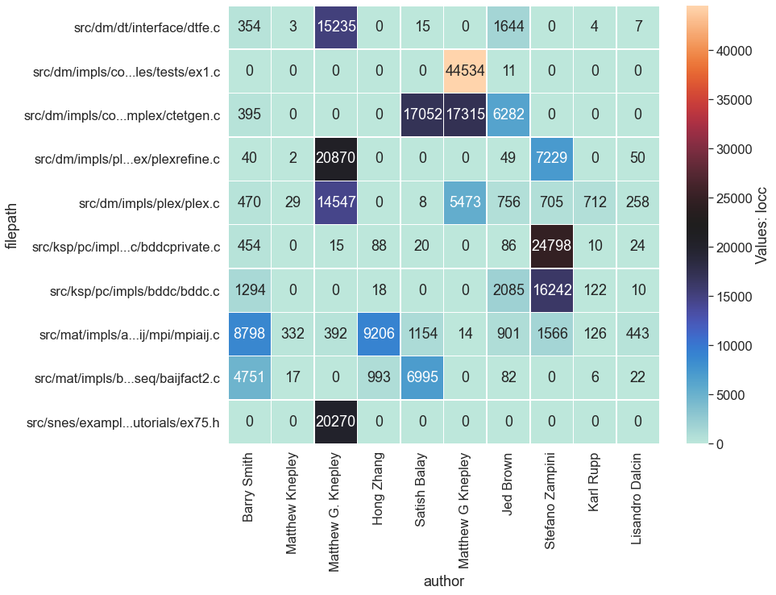

```python
N = 10
vis.set_max_label_length(30)
top_N = vis.plot_top_N_heatmap(N, value_column='locc')
top_N.head()
```

| author filepath | Barry Smith | Satish Balay | Matthew Knepley | Hong Zhang | Matthew G. Knepley | Jed Brown | Lisandro Dalcin | Stefano Zampini | Lois Curfman McInnes | Matthew G Knepley |
| --- | --- | --- | --- | --- | --- | --- | --- | --- | --- | --- |
| config/builder.py | 10.891178 | 2.273194 | 0.751614 | 0.000000 | 102.053895 | 3.303464 | 0.020764 | 1.000000 | 0.000000 | 98.220817 |
| src/dm/impls/plex/plex.c | 8.624471 | 1.273819 | 1.659920 | 0.000000 | 148.866835 | 15.156714 | 1.603873 | 11.851066 | 0.000000 | 18.464128 |
| src/dm/interface/dm.c | 45.379085 | 3.164801 | 2.706598 | 1.027471 | 90.123598 | 22.368472 | 5.143633 | 12.613315 | 0.000000 | 26.677957 |
| src/mat/impls/a...ij/mpi/mpiaij.c | 165.305361 | 23.887829 | 11.213453 | 110.742325 | 2.435439 | 20.673647 | 2.065844 | 16.988183 | 24.524507 | 2.250280 |
| src/mat/impls/aij/seq/aij.c | 173.071765 | 21.960970 | 10.559950 | 84.445100 | 1.255744 | 18.032087 | 4.113082 | 15.527216 | 14.550668 | 0.685473 |

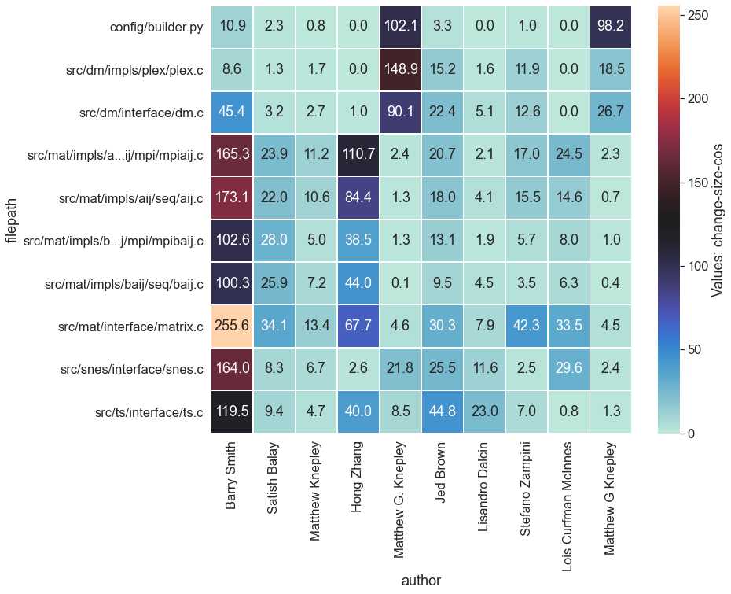

```python
import seaborn as sns
top_N = vis.plot_top_N_heatmap(N, value_column='change-size-cos')
top_N.head()
```

```python
from patterns.patterns import Patterns
df = vis.commit_data
```

```python
vis.reset()
vis.annotate_metrics(diff_alg='cos')
file_dev_locc = vis.make_file_developer_df(value_column='locc')
file_dev_diff = vis.make_file_developer_df(value_column='change-size-cos')
```

```python
diff_df = file_dev_locc.sub(file_dev_diff, axis=0)
print(diff_df.shape)
diff_df.head()
```

```
(8195, 268)
```

| author filepath |  | Adam Denchfield | Adam Oberman | Administrator | Adrian Croucher | Adrian Maldonado | Adrián Németh | Albert Cowie | Alejandro Lamas Daviña | Alejandro Otero | ... | tmunson | unknown | valeriabarra | victor | victorle | xavier lacoste | xht | xuemin | zianekhodja | “Marek |
| --- | --- | --- | --- | --- | --- | --- | --- | --- | --- | --- | --- | --- | --- | --- | --- | --- | --- | --- | --- | --- | --- |
| .dir-locals.el | 0.0 | 0.0 | 0.0 | 0.0 | 0.0 | 0.0 | 0.0 | 0.0 | 0.0 | 0.0 | ... | 0.0 | 0.0 | 0.0 | 0.0 | 0.0 | 0.0 | 0.0 | 0.0 | 0.0 | 0.0 |
| .gitlab-alcf-ci.yaml | 0.0 | 0.0 | 0.0 | 0.0 | 0.0 | 0.0 | 0.0 | 0.0 | 0.0 | 0.0 | ... | 0.0 | 0.0 | 0.0 | 0.0 | 0.0 | 0.0 | 0.0 | 0.0 | 0.0 | 0.0 |
| .gitlab-ci.yml | 0.0 | 0.0 | 0.0 | 0.0 | 0.0 | 0.0 | 0.0 | 0.0 | 0.0 | 0.0 | ... | 0.0 | 0.0 | 0.0 | 0.0 | 0.0 | 0.0 | 0.0 | 0.0 | 0.0 | 0.0 |
| .readthedocs.yml | 0.0 | 0.0 | 0.0 | 0.0 | 0.0 | 0.0 | 0.0 | 0.0 | 0.0 | 0.0 | ... | 0.0 | 0.0 | 0.0 | 0.0 | 0.0 | 0.0 | 0.0 | 0.0 | 0.0 | 0.0 |
| .travis.yml | 0.0 | 0.0 | 0.0 | 0.0 | 0.0 | 0.0 | 0.0 | 0.0 | 0.0 | 0.0 | ... | 0.0 | 0.0 | 0.0 | 0.0 | 0.0 | 0.0 | 0.0 | 0.0 | 0.0 | 0.0 |

5 rows × 268 columns

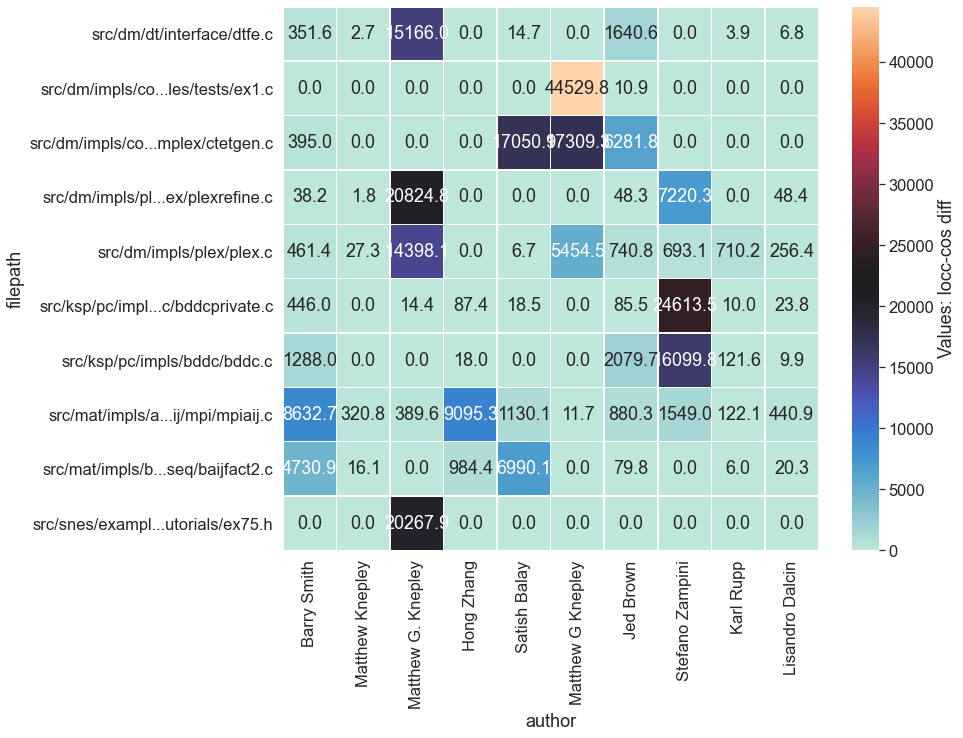

```python
df = vis.commit_data
df['locc-cos diff'] = df['locc']-df['change-size-cos']
d = vis.plot_top_N_heatmap(top_N = 10, value_column='locc-cos diff', my_df=df)
```